# A review of inference concepts

Statistical Programming with R

## Topics this lecture

- Probability distributions in `R`
- A review of statistical inference concepts

## Probability distributions

- Normal distributions
  - Linear model
  - error distribution is normal
- Discrete distributions (counts)
  - Bernoulli, Binomial or Poisson model
  - error distribution not normal
- Other continuous distributions
  - Uniform, exponential
  - error distribution not normal

## Probability distributions in R

R has a system to work with probability distributions. For example the normal distribution:

`dnorm()`: **d** for density function

`pnorm()`: **p** for cumulative distribution \(P(X \leqslant x)\)

`qnorm()`: **q** for p-quantile

`rnorm()`: **r** for pseudo-random normally distributed numbers

For other distributions, replace `norm` with: `f, chisq, binom, pois, exp, unif, gamma, beta, t`

Example: obtain critical *z*-value for a 2-sided 95% confidence interval:

```r
qnorm(0.975) # default: mean=0, sd=1
```

```
## [1] 1.959964
```

## A review of inference concepts

## Parameters and statistics

Random sample

- set of values drawn independently from a population

Population parameter

- Property of the population (e.g. \(\mu,\sigma,\rho\))

Sample statistic

- Property of the sample (e.g. \(\bar{x},s,r\))

## Sampling distributions

The sampling distribution is the distribution of a sample statistic

### Central Limit Theorem

- **Given a distribution with mean \(\mu\) and standard deviation \(\sigma\), the sampling distribution of the mean approaches a normal distribution with mean \(\mu\) and standard deviation \(\frac{\sigma}{\sqrt{n}}\) as \(n\to\infty\)**

Conditions for the CLT to hold

- \(\mu\) and \(\sigma\) known
- the sample size \(n\) is sufficiently large

## Hypothesis tests and confidence intervals

## Hypothesis tests

Statistical tests work with a null hypothesis, e.g.: \[ H_0:\mu=\mu_0 \]

- If population parameters \(\mu\) and \(\sigma\) are unknown, we need to use sample mean \(\bar{x}\) and sample standard deviation \(s\) as estimators
- as a consequence, the sample mean has a \(t\)-distribution

\[ t_{(df)}=\frac{\bar{x}-\mu_0}{SEM} \]

## \(t\)-distribution

The \(t\)-distribution has larger variance than the normal distribution (more uncertainty).

- degrees of freedom: \(df=n-\) number of estimated means
- the higher the degrees of freedom (the larger the sample) the more it resembles a normal distribution

## \(t\)-distribution vs normal

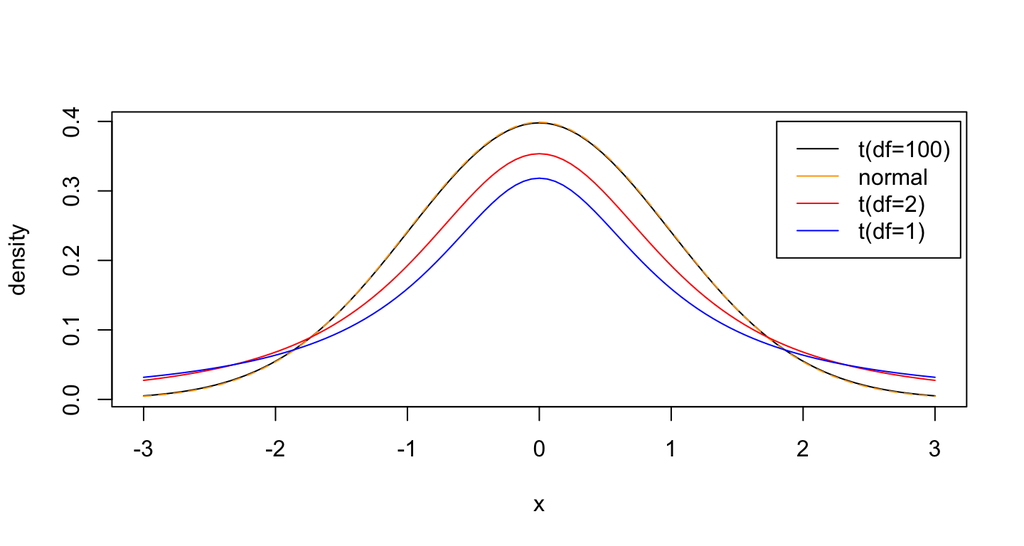

```r
curve(dt(x, 100), -3, 3, ylab = "density")
curve(dnorm(x), -3, 3, ylab = "", add = TRUE, col = "orange", lty=2)
curve(dt(x,   2), -3, 3, ylab = "", add = TRUE, col = "red")
curve(dt(x,   1), -3, 3, ylab = "", add = TRUE, col = "blue")
legend(1.8, .4, c("t(df=100)", "normal", "t(df=2)", "t(df=1)"),
       col = c("black", "orange", "red", "blue"), lty=1)
```

## \(p\)-values

The \(p\)-value in this situation is the probability that \(\bar{x}\) is at least that much different from \(\mu_0\):

- P(\(\bar{X}\) \(\geq\) \(\bar{x}\) |\(\mu\)=0)

We would reject \(H_0\) if \(p\) is smaller than the experimenters’ predetermined significance level \(\alpha\):

- two-sided test if \(H_A:\mu\neq\mu_0\) (upper and lower (\(\alpha\)/2) * 100%)
- one-sided test if \(H_A:\mu>\mu_0\) or \(H_A:\mu<\mu_0\) (upper or lower \(\alpha\) * 100%)